# Comparing NLCD tree canopy datasets, 2011-2021

Author

Kent Johnson

### Introduction

The two tree canopy change reports for Northampton (2011-2021, 1985-2023) draw on two different releases of NLCD Tree Canopy Cover (TCC) data: an older release covering 2011-2021 (`v2021-4`), and a newer release covering 1985-2023 (`v2023-5`). Both releases report data for the overlapping 2011-2021 period, but the reported coverage values differ meaningfully between them.

This report plots both datasets’ values for 2011-2021 together, so the size and shape of the discrepancy is visible at the same summary level the two source reports already report at — citywide, by city center, and by zoning category. Dashed lines are the older (`v2021-4`) dataset; solid lines are the newer (`v2023-5`) dataset restricted to 2011-2021.

For a raster-level, year-by-year comparison of any two individual layers on a map, see the tree canopy layer comparison tool.

### Tree canopy in Northampton

This chart shows citywide tree canopy coverage for 2011-2021 as reported by each dataset.

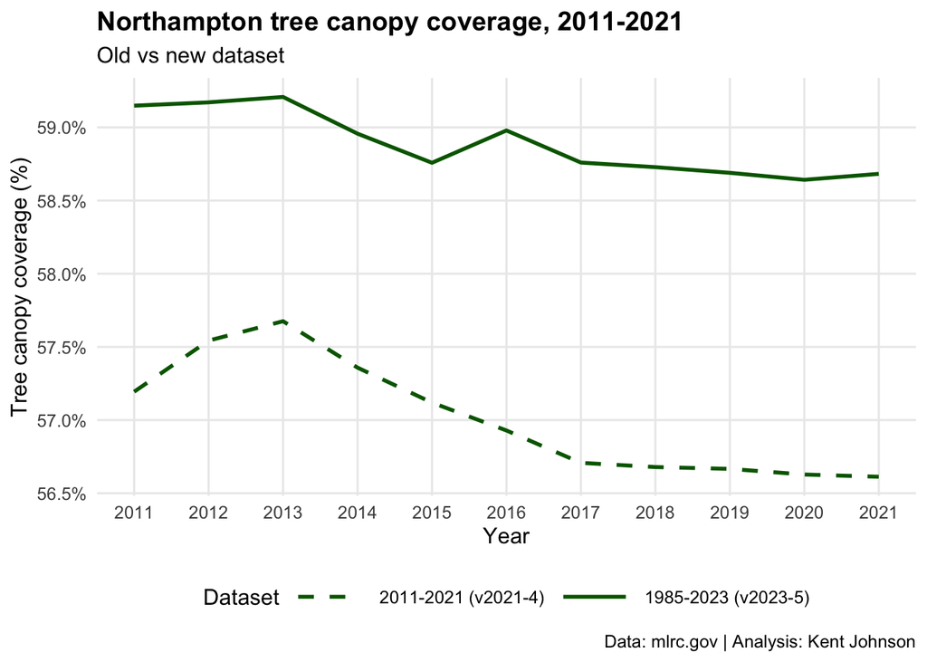

The next chart shows the same data as change since the 2011 baseline, computed separately within each dataset.

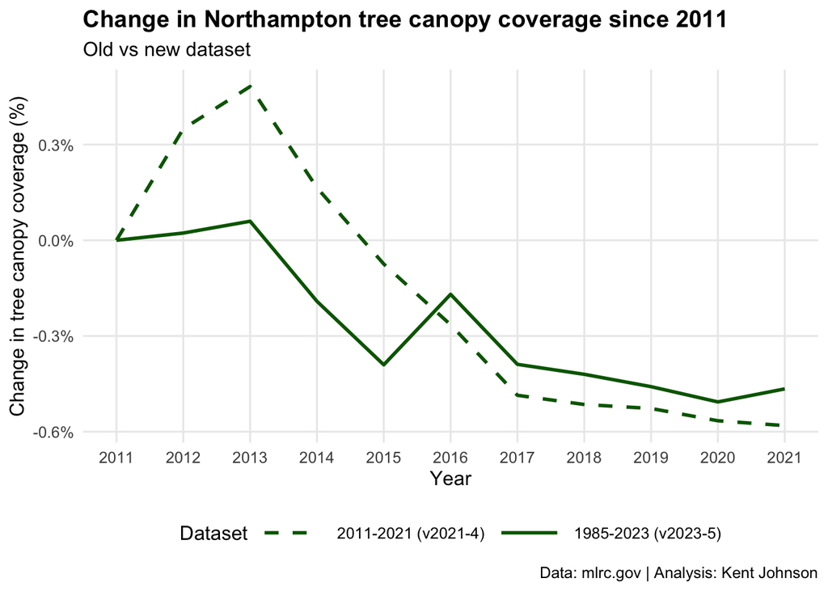

This table shows the citywide coverage percent reported by each dataset for every year 2011-2021, and the difference between them.

Citywide tree canopy coverage: old vs new dataset, 2011-2021

| Year | Old (v2021-4) | New (v2023-5) | Difference |
| --- | --- | --- | --- |
| 2011 | 57.2% | 59.1% | 2.0% |
| 2012 | 57.5% | 59.2% | 1.6% |
| 2013 | 57.7% | 59.2% | 1.5% |
| 2014 | 57.4% | 59.0% | 1.6% |
| 2015 | 57.1% | 58.8% | 1.6% |
| 2016 | 56.9% | 59.0% | 2.1% |
| 2017 | 56.7% | 58.8% | 2.1% |
| 2018 | 56.7% | 58.7% | 2.0% |
| 2019 | 56.7% | 58.7% | 2.0% |
| 2020 | 56.6% | 58.6% | 2.0% |
| 2021 | 56.6% | 58.7% | 2.1% |

Data: [Multi-Resolution Land Characteristics Consortium](https://www.mrlc.gov/) | Analysis: Kent S Johnson

### Tree canopy in city centers

These charts show tree canopy coverage within the three city centers of Northampton, as reported by each dataset.

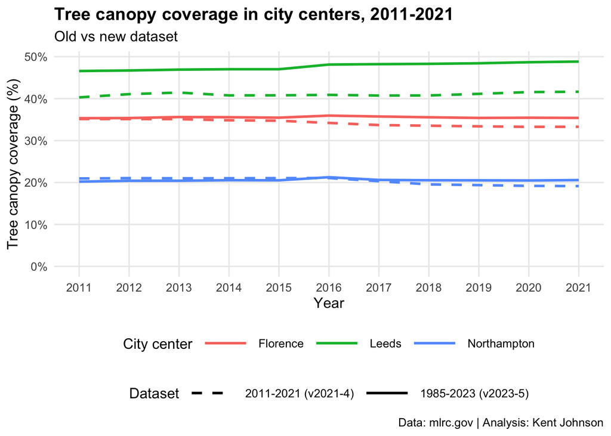

The next chart shows the change in coverage since the 2011 baseline, computed separately within each dataset and city center.

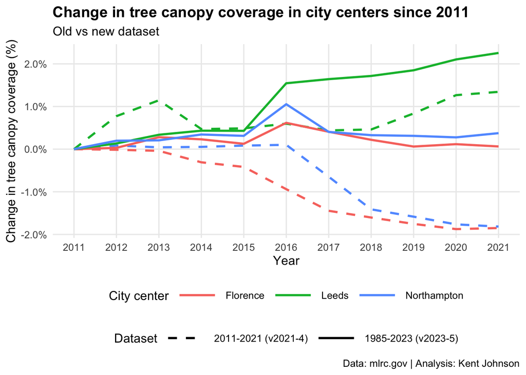

### Tree canopy by zoning category

These charts show tree canopy coverage within five aggregated zoning categories, as reported by each dataset.

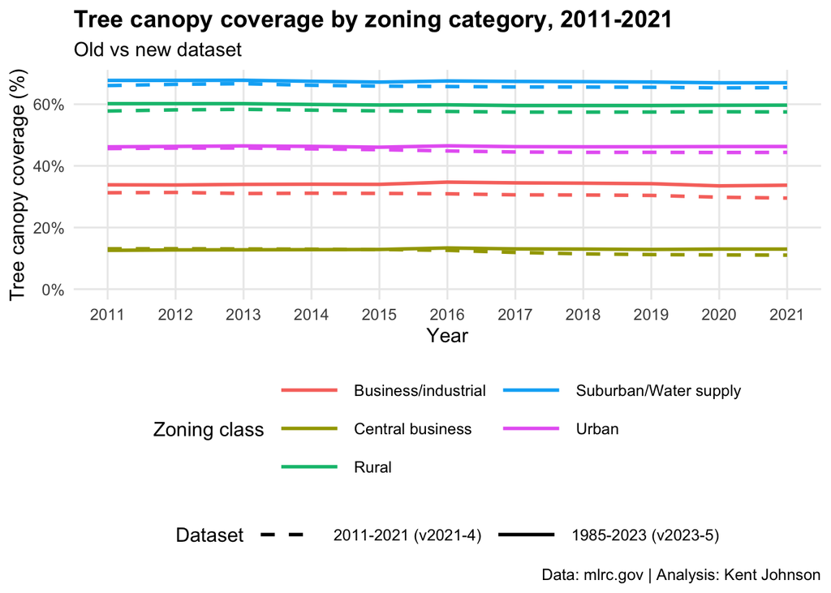

The next chart shows the change in coverage since the 2011 baseline, computed separately within each dataset and zoning category.

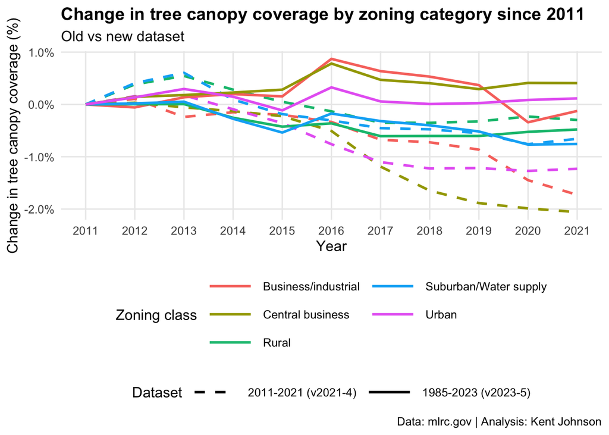

Copyright 2026 Kent S Johnson 2026-07-06